# IPW-GEE Complete Implementation Guide

Inverse Probability Weighted GEE for MAR Missingness

## 1. Why IPW-GEE?

### The Problem with Standard GEE

Standard GEE (Generalized Estimating Equations) provides valid inference for **marginal** parameters when data are **Missing Completely At Random (MCAR)**. However, under **Missing At Random (MAR)**, standard GEE becomes biased.

**ImportantKey Insight**

Standard GEE treats all observations equally, implicitly assuming that observed data are representative of the complete data. Under MAR, this assumption fails because missingness depends on observed values.

### Why Standard GEE Fails Under MAR

Consider a longitudinal study where patients with higher previous outcomes are more likely to drop out:

| Scenario | What GEE “sees” | Reality |
| --- | --- | --- |
| Complete data | All trajectories | True population |
| MAR dropout | More “favorable” trajectories | Biased toward completers |

Under MAR, the subjects who remain in the study are **systematically different** from those who drop out. Standard GEE naively uses the remaining data, leading to biased estimates.

### The IPW Solution

**Inverse Probability Weighting (IPW)** corrects this by:

1. **Modeling** the probability of being observed: $\pi_{ij} = P(R_{ij} = 1 \mid \text{History})$
2. **Weighting** each observation by $w_{ij} = 1/\pi_{ij}$
3. **Upweighting** subjects who are similar to dropouts

**TipIntuition**

If a subject with certain characteristics has only a 50% chance of being observed, we weight their observation by 2. This makes them “count” for themselves and for similar subjects who dropped out.

### Connection to Survey Sampling

IPW-GEE has a direct connection to **survey sampling weights**:

| Survey Sampling | IPW-GEE |
| --- | --- |
| Sample from population with known probabilities | Subjects “sampled” into observed data |
| Weight = 1/(selection probability) | Weight = 1/(observation probability) |
| Makes sample representative of population | Makes observed data representative of complete data |

The Horvitz-Thompson estimator in survey sampling is the direct analog of IPW in missing data contexts.

## 2. The IPW-GEE Approach

### Overview of the Four Steps

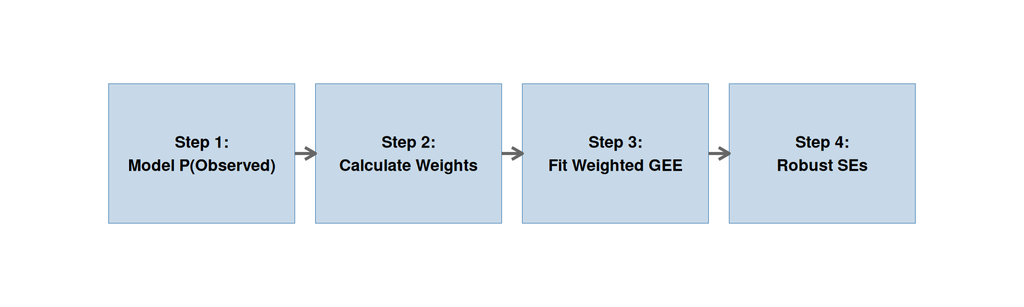

Figure 1: The four steps of IPW-GEE

### Step 1: Model the Probability of Being Observed

Fit a model for the probability that observation $j$ for subject $i$ is observed, conditional on the history:

$$\text{logit}(\pi_{ij}) = \gamma_0 + \gamma_1 X_i + \gamma_2 Y_{i,j-1} + \gamma_3 t_j + \ldots$$

where:

- $R_{ij}$ is the indicator that $Y_{ij}$ is observed (1 = observed, 0 = missing)
- $X_i$ are baseline covariates
- $Y_{i,j-1}$ is the previous outcome (if available)
- $t_j$ is the time point

**WarningMonotone vs. Non-monotone Missingness**

For **monotone dropout** (once missing, always missing), model the probability of dropping out at time $t$ given observed through time $t-1$. For **intermittent missingness**, model the probability of being observed at each time point.

### Step 2: Calculate Inverse Probability Weights

For each observed response:

$$w_{ij} = \frac{1}{\pi_{ij}} = \frac{1}{P(R_{ij} = 1 \mid \text{History})}$$

For **monotone dropout**, the weight for observation at time $t$ is:

$$w_{it} = \prod_{s=1}^{t} \frac{1}{\pi_{is}} = \frac{1}{P(\text{observed through time } t)}$$

### Step 3: Fit Weighted GEE

Use the weights in the GEE estimating equations:

$$U(\beta) = \sum_{i=1}^{n} D_i^T V_i^{-1} W_i (Y_i - \mu_i) = 0$$

where $W_i = \text{diag}(w_{i1}, w_{i2}, \ldots, w_{in_i})$ is the diagonal matrix of weights.

### Step 4: Use Robust (Sandwich) Standard Errors

The variance estimator must account for:

1. The estimation of weights (if not accounted for, SEs are conservative)
2. Potential misspecification of the correlation structure

**Always use robust sandwich standard errors** with IPW-GEE.

## 3. Weight Calculation

### Standard vs. Stabilized Weights

#### Standard Weights

$$w_{ij} = \frac{1}{\pi_{ij}}$$

**Problem**: If $\pi_{ij}$ is small (e.g., 0.05), the weight is large (e.g., 20), leading to:

- High variability in estimates
- Unstable inference
- Sensitivity to model misspecification

#### Stabilized Weights (Recommended)

$$w_{ij}^{stab} = \frac{\pi_{marginal}}{\pi_{ij}} = \frac{P(R_{ij} = 1)}{P(R_{ij} = 1 \mid \text{History})}$$

where $\pi_{marginal}$ is the marginal probability of being observed (not conditional on covariates).

**Benefits of stabilized weights**:

| Property | Standard Weights | Stabilized Weights |
| --- | --- | --- |
| Mean | Can be > 1 | Approximately 1 |
| Variance | Higher | Lower |
| Extreme values | More common | Less common |
| Efficiency | Lower | Higher |

**TipRule of Thumb**

Stabilized weights should have a mean close to 1. If the mean is substantially different from 1, there may be issues with the weight model.

### Weight Formula for Monotone Dropout

For monotone (sequential) dropout where subjects drop out and never return:

$$\pi_{it} = P(D_i > t \mid D_i > t-1, \text{History}_{t-1})$$

where $D_i$ is the dropout time for subject $i$.

The cumulative weight for observation at time $t$:

$$w_{it} = \prod_{s=1}^{t} \frac{1}{\pi_{is}}$$

### Code: Weight Calculation

```r
# Step 1: Fit logistic model for P(observed)
weight_model <- glm(
  observed ~ time + lag_outcome + treatment + baseline_severity,
  data = data_for_weights,
  family = binomial(link = "logit")
)

# Step 2: Get predicted probabilities
data$pi_ij <- predict(weight_model, type = "response")

# Step 3: Calculate standard weights
data$weight <- 1 / data$pi_ij

# Step 4: Calculate stabilized weights
# Marginal probability of being observed at each time
marginal_pi <- data |>
  group_by(time) |>
  summarize(pi_marginal = mean(observed)) |>
  ungroup()

data <- left_join(data, marginal_pi, by = "time")
data$weight_stabilized <- data$pi_marginal / data$pi_ij
```

## 4. Complete R Implementation

### Step-by-Step Code

```r
# ============================================================
# IPW-GEE: Complete Implementation
# ============================================================

# --- Step 1: Create Example Data with MAR Dropout ---

set.seed(667)

n_subjects <- 200
n_times <- 5

# Generate complete data
data_complete <- expand.grid(
  time = 1:n_times,
  subject = 1:n_subjects
) |>
  arrange(subject, time) |>
  mutate(
    treatment = rep(rbinom(n_subjects, 1, 0.5), each = n_times)
  ) |>
  group_by(subject) |>
  mutate(
    b0 = rnorm(1, 0, sd = 3)[1],  # Random intercept
    y_complete = 10 + 2*time + 3*treatment + b0 + rnorm(n(), 0, 2)
  ) |>
  ungroup()

# Create MAR dropout: higher previous Y -> higher dropout probability
data_mar <- data_complete |>
  group_by(subject) |>
  mutate(
    y_lag = lag(y_complete),
    # Dropout probability depends on previous Y
    p_dropout = ifelse(is.na(y_lag), 0, plogis(-4 + 0.2*y_lag)),
    # Monotone dropout
    dropped = cumsum(runif(n()) < p_dropout) > 0,
    dropped = ifelse(time == 1, FALSE, dropped),
    # Observed outcome
    y_obs = ifelse(dropped, NA, y_complete),
    # Observation indicator
    observed = as.numeric(!is.na(y_obs))
  ) |>
  ungroup()

cat("Observation rates by time:\n")
```

```
Observation rates by time:
```

```r
data_mar |>
  group_by(time) |>
  summarize(pct_observed = round(100*mean(observed), 1)) |>
  print()
```

```
# A tibble: 5 × 2
   time pct_observed
  <int>        <dbl>
1     1        100
2     2         77
3     3         57.5
4     4         37.5
5     5         23.5
```

```r
# --- Step 2: Fit Model for P(Observed) ---

# For weight modeling, we need lagged outcome from observed data
data_for_weights <- data_mar |>
  group_by(subject) |>
  mutate(
    # Lagged observed outcome (last observed value)
    y_lag_obs = lag(y_obs),
    # For subjects still in study, use their lagged value
    # Fill forward for those with missing lag
    y_lag_filled = ifelse(is.na(y_lag_obs) & time > 1,
                          NA, y_lag_obs)
  ) |>
  ungroup() |>
  # Only include times where we can model (time > 1, and previous obs available)
  filter(time > 1)

# Remove rows where lagged outcome is missing (can't compute weight)
data_for_weights_complete <- data_for_weights |>
  filter(!is.na(y_lag_filled))

# Fit logistic regression for observation probability
weight_model <- glm(
  observed ~ time + y_lag_filled + treatment,
  data = data_for_weights_complete,
  family = binomial(link = "logit")
)

summary(weight_model)
```

```
Call:
glm(formula = observed ~ time + y_lag_filled + treatment, family = binomial(link = "logit"),
    data = data_for_weights_complete)

Coefficients:
              Estimate Std. Error z value Pr(>|z|)
(Intercept)   3.586991   0.462075   7.763 8.31e-15 ***
time          0.001178   0.102801   0.011    0.991
y_lag_filled -0.167543   0.029665  -5.648 1.62e-08 ***
treatment     0.047160   0.209078   0.226    0.822
---
Signif. codes:  0 '***' 0.001 '**' 0.01 '*' 0.05 '.' 0.1 ' ' 1

(Dispersion parameter for binomial family taken to be 1)

    Null deviance: 646.41  on 543  degrees of freedom
Residual deviance: 600.56  on 540  degrees of freedom
AIC: 608.56

Number of Fisher Scoring iterations: 4
```

```r
# --- Step 3: Calculate Weights ---

# Get predicted probabilities
data_for_weights_complete$pi_hat <- predict(weight_model, type = "response")

# Standard weights
data_for_weights_complete$weight <- 1 / data_for_weights_complete$pi_hat

# Stabilized weights
# Calculate marginal observation probability by time
marginal_probs <- data_for_weights_complete |>
  group_by(time) |>
  summarize(pi_marginal = mean(observed)) |>
  ungroup()

data_for_weights_complete <- left_join(
  data_for_weights_complete, marginal_probs, by = "time"
)

data_for_weights_complete$weight_stab <-
  data_for_weights_complete$pi_marginal / data_for_weights_complete$pi_hat

# Summary of weights
cat("Weight Summary:\n")
```

```
Weight Summary:
```

```r
cat("\nStandard weights:\n")
```

```
Standard weights:
```

```r
summary(data_for_weights_complete$weight)
```

```
   Min. 1st Qu.  Median    Mean 3rd Qu.    Max.
  1.044   1.215   1.336   1.448   1.583   3.251
```

```r
cat("\nStabilized weights:\n")
```

```
Stabilized weights:
```

```r
summary(data_for_weights_complete$weight_stab)
```

```
   Min. 1st Qu.  Median    Mean 3rd Qu.    Max.
 0.7047  0.8937  0.9832  1.0335  1.1243  2.5032
```

```r
# --- Step 4: Fit Weighted GEE ---

# Prepare data for GEE (only observed outcomes)
gee_data <- data_for_weights_complete |>
  filter(observed == 1) |>
  mutate(subject = factor(subject))

# Add time 1 observations (no weights needed, everyone observed)
time1_data <- data_mar |>
  filter(time == 1) |>
  mutate(
    weight = 1,
    weight_stab = 1,
    subject = factor(subject)
  ) |>
  select(subject, time, treatment, y_obs, weight, weight_stab)

gee_data_final <- bind_rows(
  time1_data,
  gee_data |> select(subject, time, treatment, y_obs, weight, weight_stab)
) |>
  arrange(subject, time) |>
  filter(!is.na(y_obs))

# Fit IPW-GEE with stabilized weights
ipw_gee_fit <- geeglm(
  y_obs ~ time + treatment,
  data = gee_data_final,
  id = subject,
  weights = weight_stab,
  family = gaussian,
  corstr = "independence"  # Independence is standard for IPW-GEE
)

cat("\n=== IPW-GEE Results ===\n")
```

```
=== IPW-GEE Results ===
```

```r
summary(ipw_gee_fit)
```

```
Call:
geeglm(formula = y_obs ~ time + treatment, family = gaussian,
    data = gee_data_final, weights = weight_stab, id = subject,
    corstr = "independence")

 Coefficients:
            Estimate Std.err  Wald Pr(>|W|)
(Intercept)  10.6980  0.4103 679.7  < 2e-16 ***
time          1.7564  0.1002 307.0  < 2e-16 ***
treatment     2.2735  0.4782  22.6 1.99e-06 ***
---
Signif. codes:  0 '***' 0.001 '**' 0.01 '*' 0.05 '.' 0.1 ' ' 1

Correlation structure = independence
Estimated Scale Parameters:

            Estimate Std.err
(Intercept)    12.51  0.9878
Number of clusters:   200  Maximum cluster size: 5
```

## 5. Weight Diagnostics

### Why Diagnostics Matter

Extreme weights can lead to:

- Inflated variance
- Unstable estimates
- Sensitivity to individual observations

**WarningWarning Signs**

- Maximum weight > 10-20
- Large gap between mean and median
- Highly skewed distribution

### Diagnostic Visualizations

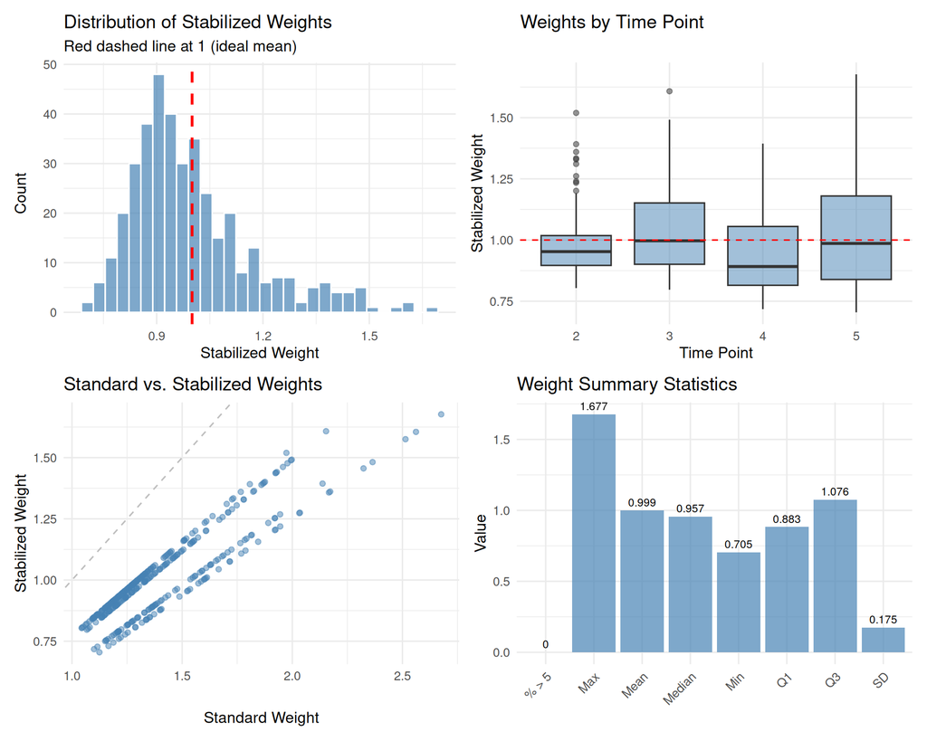

Figure 2: Weight distribution diagnostics

```r
# Prepare diagnostic data
diag_data <- gee_data_final |>
  filter(time > 1)  # Weights only relevant for time > 1

p1 <- ggplot(diag_data, aes(x = weight_stab)) +
  geom_histogram(bins = 30, fill = "steelblue", color = "white", alpha = 0.7) +
  geom_vline(xintercept = 1, linetype = "dashed", color = "red", linewidth = 1) +
  labs(x = "Stabilized Weight",
       y = "Count",
       title = "Distribution of Stabilized Weights",
       subtitle = "Red dashed line at 1 (ideal mean)") +
  theme_minimal(base_size = 12)

p2 <- ggplot(diag_data, aes(x = factor(time), y = weight_stab)) +
  geom_boxplot(fill = "steelblue", alpha = 0.5) +
  geom_hline(yintercept = 1, linetype = "dashed", color = "red") +
  labs(x = "Time Point",
       y = "Stabilized Weight",
       title = "Weights by Time Point") +
  theme_minimal(base_size = 12)

p3 <- ggplot(diag_data, aes(x = weight, y = weight_stab)) +
  geom_point(alpha = 0.5, color = "steelblue") +
  geom_abline(slope = 1, intercept = 0, linetype = "dashed", color = "gray") +
  labs(x = "Standard Weight",
       y = "Stabilized Weight",
       title = "Standard vs. Stabilized Weights") +
  theme_minimal(base_size = 12)

# Summary statistics
weight_summary <- diag_data |>
  summarize(
    Mean = mean(weight_stab),
    SD = sd(weight_stab),
    Min = min(weight_stab),
    Q1 = quantile(weight_stab, 0.25),
    Median = median(weight_stab),
    Q3 = quantile(weight_stab, 0.75),
    Max = max(weight_stab),
    `% > 5` = 100*mean(weight_stab > 5)
  ) |>
  pivot_longer(everything(), names_to = "Statistic", values_to = "Value") |>
  mutate(Value = round(Value, 3))

p4 <- ggplot(weight_summary, aes(x = Statistic, y = Value)) +
  geom_col(fill = "steelblue", alpha = 0.7) +
  geom_text(aes(label = Value), vjust = -0.5, size = 3) +
  labs(title = "Weight Summary Statistics",
       x = "", y = "Value") +
  theme_minimal(base_size = 12) +
  theme(axis.text.x = element_text(angle = 45, hjust = 1))

library(patchwork)
(p1 + p2) / (p3 + p4)
```

### Weight Truncation Strategies

When weights are extreme, consider truncation:

```r
# Method 1: Truncate at percentiles
truncate_weights_percentile <- function(weights, lower = 0.01, upper = 0.99) {
  bounds <- quantile(weights, c(lower, upper))
  pmin(pmax(weights, bounds[1]), bounds[2])
}

# Method 2: Truncate at fixed values
truncate_weights_fixed <- function(weights, max_weight = 10) {
  pmin(weights, max_weight)
}

# Apply truncation
gee_data_final$weight_trunc <- truncate_weights_percentile(gee_data_final$weight_stab)

cat("Original weights - Max:", max(gee_data_final$weight_stab), "\n")
```

```
Original weights - Max: 1.677
```

```r
cat("Truncated weights - Max:", max(gee_data_final$weight_trunc), "\n")
```

```
Truncated weights - Max: 1.489
```

**TipTruncation Guidelines**

- **Percentile truncation** (1st and 99th) is often more robust
- **Fixed truncation** at 10-20 is common in practice
- Report sensitivity to truncation threshold
- Truncation introduces some bias but reduces variance (bias-variance tradeoff)

## 6. Worked Example: Comparing Methods

### Simulation Setup

We simulate longitudinal data where:

- True time effect: $\beta_{time} = 2$
- True treatment effect: $\beta_{trt} = 3$
- Dropout depends on previous observed outcome (MAR)

```r
set.seed(667)

# Simulation parameters
n_sims <- 200
n_subjects <- 200
n_times <- 5
beta_time_true <- 2
beta_trt_true <- 3

# Storage
results <- data.frame(
  sim = integer(),
  method = character(),
  parameter = character(),
  estimate = numeric(),
  se = numeric()
)

for (s in 1:n_sims) {

  # Generate data
  sim_data <- expand.grid(
    time = 1:n_times,
    subject = 1:n_subjects
  ) |>
    arrange(subject, time) |>
    mutate(
      treatment = rep(rbinom(n_subjects, 1, 0.5), each = n_times)
    ) |>
    group_by(subject) |>
    mutate(
      b0 = rnorm(1, 0, sd = 3)[1],
      y_complete = 10 + beta_time_true*time + beta_trt_true*treatment +
                   b0 + rnorm(n(), 0, 2)
    ) |>
    ungroup()

  # MAR dropout
  sim_data <- sim_data |>
    group_by(subject) |>
    mutate(
      y_lag = lag(y_complete),
      p_dropout = ifelse(is.na(y_lag), 0, plogis(-4 + 0.2*y_lag)),
      dropped = cumsum(runif(n()) < p_dropout) > 0,
      dropped = ifelse(time == 1, FALSE, dropped),
      y_obs = ifelse(dropped, NA, y_complete),
      observed = as.numeric(!is.na(y_obs))
    ) |>
    ungroup()

  # ========================================
  # Method 1: Unweighted GEE (BIASED)
  # ========================================
  gee_data_unweighted <- sim_data |>
    filter(!is.na(y_obs)) |>
    mutate(subject = factor(subject))

  fit_gee_uw <- tryCatch({
    geeglm(y_obs ~ time + treatment, data = gee_data_unweighted,
           id = subject, family = gaussian, corstr = "independence")
  }, error = function(e) NULL)

  if (!is.null(fit_gee_uw)) {
    coefs <- summary(fit_gee_uw)$coefficients
    results <- rbind(results, data.frame(
      sim = s,
      method = "Unweighted GEE",
      parameter = c("time", "treatment"),
      estimate = coefs[c("time", "treatment"), "Estimate"],
      se = coefs[c("time", "treatment"), "Std.err"]
    ))
  }

  # ========================================
  # Method 2: IPW-GEE (APPROXIMATELY UNBIASED)
  # ========================================

  # Weight model data
  weight_data <- sim_data |>
    group_by(subject) |>
    mutate(y_lag_obs = lag(y_obs)) |>
    ungroup() |>
    filter(time > 1, !is.na(y_lag_obs))

  if (nrow(weight_data) > 50) {
    weight_mod <- tryCatch({
      glm(observed ~ time + y_lag_obs + treatment,
          data = weight_data, family = binomial)
    }, error = function(e) NULL)

    if (!is.null(weight_mod)) {
      weight_data$pi_hat <- predict(weight_mod, type = "response")
      weight_data$weight <- 1 / pmax(weight_data$pi_hat, 0.05)  # Truncate

      # Stabilize
      marg <- weight_data |>
        group_by(time) |>
        summarize(pi_marg = mean(observed))
      weight_data <- left_join(weight_data, marg, by = "time")
      weight_data$weight_stab <- weight_data$pi_marg /
                                  pmax(weight_data$pi_hat, 0.05)

      # GEE data
      gee_ipw <- weight_data |>
        filter(observed == 1) |>
        mutate(subject = factor(subject))

      # Add time 1
      t1 <- sim_data |>
        filter(time == 1) |>
        mutate(weight_stab = 1, subject = factor(subject)) |>
        select(subject, time, treatment, y_obs, weight_stab)

      gee_ipw_final <- bind_rows(
        t1,
        gee_ipw |> select(subject, time, treatment, y_obs, weight_stab)
      ) |>
        arrange(subject, time)

      fit_ipw <- tryCatch({
        geeglm(y_obs ~ time + treatment, data = gee_ipw_final,
               id = subject, weights = weight_stab,
               family = gaussian, corstr = "independence")
      }, error = function(e) NULL)

      if (!is.null(fit_ipw)) {
        coefs <- summary(fit_ipw)$coefficients
        results <- rbind(results, data.frame(
          sim = s,
          method = "IPW-GEE",
          parameter = c("time", "treatment"),
          estimate = coefs[c("time", "treatment"), "Estimate"],
          se = coefs[c("time", "treatment"), "Std.err"]
        ))
      }
    }
  }

  # ========================================
  # Method 3: Mixed Model (APPROXIMATELY UNBIASED)
  # ========================================
  fit_mm <- tryCatch({
    lme(y_obs ~ time + treatment,
        random = ~ 1 | subject,
        data = sim_data,
        na.action = na.omit,
        method = "REML")
  }, error = function(e) NULL)

  if (!is.null(fit_mm)) {
    coefs <- summary(fit_mm)$tTable
    results <- rbind(results, data.frame(
      sim = s,
      method = "Mixed Model",
      parameter = c("time", "treatment"),
      estimate = coefs[c("time", "treatment"), "Value"],
      se = coefs[c("time", "treatment"), "Std.Error"]
    ))
  }
}
```

### Results Summary

```r
# Summarize results
summary_results <- results |>
  group_by(method, parameter) |>
  summarize(
    n_sims = n(),
    mean_est = mean(estimate),
    sd_est = sd(estimate),
    mean_se = mean(se),
    .groups = "drop"
  ) |>
  mutate(
    true_value = ifelse(parameter == "time", beta_time_true, beta_trt_true),
    bias = mean_est - true_value,
    pct_bias = 100 * bias / true_value
  )

cat("=== SIMULATION RESULTS ===\n\n")
```

```
=== SIMULATION RESULTS ===
```

```r
cat("True values: beta_time =", beta_time_true, ", beta_trt =", beta_trt_true, "\n\n")
```

```
True values: beta_time = 2 , beta_trt = 3
```

```r
# Display results
summary_results |>
  select(method, parameter, mean_est, bias, pct_bias, sd_est) |>
  mutate(across(where(is.numeric), ~round(., 3))) |>
  print(n = 20)
```

```
# A tibble: 6 × 6
  method         parameter mean_est   bias pct_bias sd_est
  <chr>          <chr>        <dbl>  <dbl>    <dbl>  <dbl>
1 IPW-GEE        time          1.70 -0.299   -15.0   0.107
2 IPW-GEE        treatment     2.95 -0.054    -1.79  0.481
3 Mixed Model    time          2.00  0.002     0.08  0.076
4 Mixed Model    treatment     3.05  0.054     1.79  0.431
5 Unweighted GEE time          1.56 -0.443   -22.1   0.11
6 Unweighted GEE treatment     2.86 -0.144    -4.80  0.453
```

### Visualization

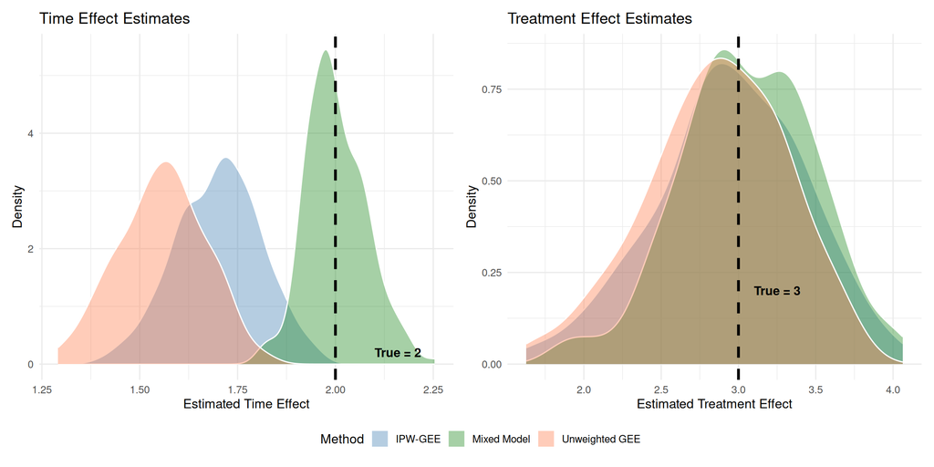

Figure 3: Comparison of methods under MAR dropout

```r
# Create comparison plot
true_values <- data.frame(
  parameter = c("time", "treatment"),
  true_value = c(beta_time_true, beta_trt_true)
)

results_plot <- results |>
  left_join(true_values, by = "parameter")

p1 <- ggplot(results_plot |> filter(parameter == "time"),
             aes(x = estimate, fill = method)) +
  geom_density(alpha = 0.4, color = "white") +
  geom_vline(xintercept = beta_time_true, linetype = "dashed",
             linewidth = 1.2, color = "black") +
  annotate("text", x = beta_time_true + 0.1, y = 0.2,
           label = paste("True =", beta_time_true),
           hjust = 0, size = 4, fontface = "bold") +
  scale_fill_manual(values = c("Unweighted GEE" = "coral",
                               "IPW-GEE" = "steelblue",
                               "Mixed Model" = "forestgreen")) +
  labs(x = "Estimated Time Effect",
       y = "Density",
       title = "Time Effect Estimates",
       fill = "Method") +
  theme_minimal(base_size = 12) +
  theme(legend.position = "bottom")

p2 <- ggplot(results_plot |> filter(parameter == "treatment"),
             aes(x = estimate, fill = method)) +
  geom_density(alpha = 0.4, color = "white") +
  geom_vline(xintercept = beta_trt_true, linetype = "dashed",
             linewidth = 1.2, color = "black") +
  annotate("text", x = beta_trt_true + 0.1, y = 0.2,
           label = paste("True =", beta_trt_true),
           hjust = 0, size = 4, fontface = "bold") +
  scale_fill_manual(values = c("Unweighted GEE" = "coral",
                               "IPW-GEE" = "steelblue",
                               "Mixed Model" = "forestgreen")) +
  labs(x = "Estimated Treatment Effect",
       y = "Density",
       title = "Treatment Effect Estimates",
       fill = "Method") +
  theme_minimal(base_size = 12) +
  theme(legend.position = "bottom")

p1 + p2 + plot_layout(guides = "collect") & theme(legend.position = "bottom")
```

### Bias Comparison

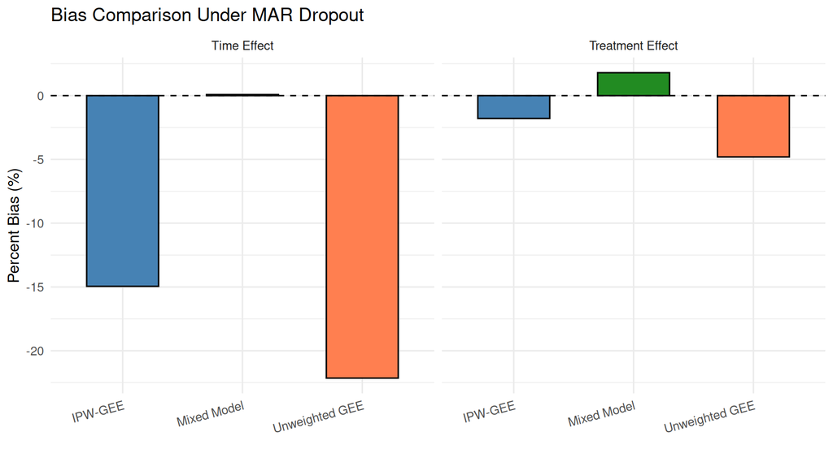

Figure 4: Percent bias by method and parameter

```r
ggplot(summary_results, aes(x = method, y = pct_bias, fill = method)) +
  geom_col(width = 0.6, color = "black") +
  geom_hline(yintercept = 0, linetype = "dashed", color = "black") +
  facet_wrap(~parameter, labeller = labeller(
    parameter = c("time" = "Time Effect", "treatment" = "Treatment Effect")
  )) +
  scale_fill_manual(values = c("Unweighted GEE" = "coral",
                               "IPW-GEE" = "steelblue",
                               "Mixed Model" = "forestgreen")) +
  labs(x = "",
       y = "Percent Bias (%)",
       title = "Bias Comparison Under MAR Dropout") +
  theme_minimal(base_size = 12) +
  theme(legend.position = "none",
        axis.text.x = element_text(angle = 15, hjust = 1))
```

## 7. Doubly Robust Estimation

### What is Doubly Robust Estimation?

**Doubly robust (DR)** estimators combine:

1. **Outcome model**: $E[Y \mid X]$ (like in standard regression)
2. **Propensity model**: $P(\text{Observed} \mid X)$ (like in IPW)

The estimator is consistent if **either** model is correctly specified (but not necessarily both).

### Intuition

| If Outcome Model Is… | And Propensity Model Is… | Then DR Estimator Is… |
| --- | --- | --- |
| Correct | Correct | Consistent (doubly protected) |
| Correct | Wrong | Consistent |
| Wrong | Correct | Consistent |
| Wrong | Wrong | Biased |

### Augmented IPW-GEE (AIPW-GEE)

The augmented IPW estimator adds a correction term:

$$\hat{\beta}_{AIPW} = \text{IPW estimate} + \text{Augmentation term}$$

The augmentation uses the outcome model to predict missing values and corrects for any bias in the IPW weights.

```r
# Conceptual code for AIPW-GEE (simplified)

# Step 1: Fit outcome model on complete cases
outcome_model <- lm(y ~ time + treatment + covariates,
                    data = data_complete_cases)

# Step 2: Predict for all observations
data$y_predicted <- predict(outcome_model, newdata = data)

# Step 3: Calculate augmented estimating equation
# The augmentation term accounts for the difference between
# observed and predicted values, weighted appropriately

# Step 4: Combine IPW with augmentation
# This is typically done using specialized software
```

**TipPractical Recommendation**

For most applications, either IPW-GEE or mixed models will suffice. Doubly robust methods are most valuable when:

1. You are uncertain about both the outcome model and the missingness model
2. High stakes decisions require extra protection against model misspecification
3. The outcome and missingness models rely on different sets of covariates

### Software for Doubly Robust Estimation

In R, doubly robust estimation for longitudinal data is available in:

- `geepack` with augmentation (manual implementation)
- `ipw` package for simpler settings
- `drtmle` for targeted learning approaches

## 8. Common Mistakes

### Mistake 1: Not Including Predictors of Missingness

**WarningProblem**

If a variable predicts missingness but is not included in the weight model, IPW will be biased.

**Example**: If sicker patients drop out and you do not include severity in the weight model, the weights will not properly adjust for this.

**Solution**: Include all variables that predict missingness in the weight model.

### Mistake 2: Extreme Weights Without Truncation

**WarningProblem**

Observations with very low probability of being observed get extremely high weights (e.g., $w = 100$), dominating the analysis.

**Solution**:

- Use stabilized weights
- Truncate weights at reasonable bounds (e.g., 1st and 99th percentiles, or max of 10-20)
- Report sensitivity to truncation

### Mistake 3: Using Model-Based Instead of Robust SEs

**WarningProblem**

Model-based standard errors assume the correlation structure is correct. With weights, this assumption is even more critical and rarely holds exactly.

**Solution**: Always use robust (sandwich) standard errors with IPW-GEE. In `geepack`, these are the default.

```r
# geepack automatically provides robust SEs
fit <- geeglm(y ~ x, data = data, id = id, weights = w,
              family = gaussian, corstr = "independence")

# The summary gives robust SEs by default
summary(fit)
```

### Mistake 4: Forgetting to Model Monotone Dropout Correctly

**WarningProblem**

For monotone dropout, you need to model the **conditional** probability of dropping out at time $t$, **given** observed through time $t-1$.

**Solution**: Model dropout hazard, not observation probability directly.

```r
# WRONG: Modeling observation at each time independently
wrong_model <- glm(observed ~ time + y_lag, data = data, family = binomial)

# CORRECT: Modeling dropout given still in study
# Only include subjects who were observed at t-1
dropout_data <- data |>
  filter(lag_observed == 1)  # Still in study at t-1

correct_model <- glm(
  dropout ~ time + y_lag + treatment,
  data = dropout_data,
  family = binomial
)
```

### Mistake 5: Ignoring Weight Model Diagnostics

**WarningProblem**

A poor weight model leads to biased estimates. Common issues:

- Model fails to converge
- Predicted probabilities near 0 or 1
- Weights have extreme outliers

**Solution**: Always check:

- Weight distribution (histogram, boxplot)
- Mean of stabilized weights (should be near 1)
- Extreme weight percentages
- Model fit statistics (AIC, deviance)

## 9. When to Use IPW-GEE vs Mixed Models

### Decision Framework

| Situation | Recommended Approach | Rationale |
| --- | --- | --- |
| MAR, interest in **marginal** effects | **IPW-GEE** | Directly estimates population-averaged effects |
| MAR, interest in **conditional** (subject-specific) effects | **Mixed Model** | Estimates conditional effects accounting for random effects |
| MAR, **both approaches** | **Sensitivity check** | Agreement provides confidence; disagreement suggests model issues |
| Substantial dropout (>30%) | **Both + sensitivity** | Heavy dropout makes assumptions harder to verify |
| Covariates predict both outcome and missingness | **Doubly robust** | Protection against misspecification |

### Key Distinctions

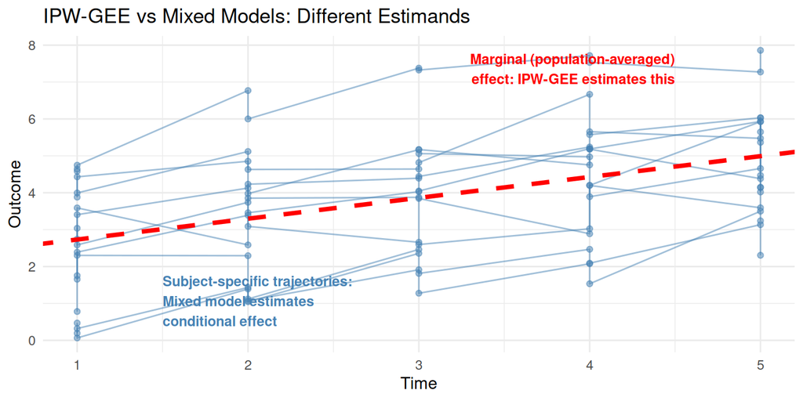

Marginal vs. conditional effects: what IPW-GEE and mixed models estimate

**NoteSummary of Method Choice**

- **IPW-GEE**: Use when you want **marginal** (population-averaged) effects and have a good understanding of the missingness mechanism
- **Mixed Model**: Use when you want **conditional** (subject-specific) effects or when the likelihood-based approach is more natural for your research question
- **Both**: When possible, fit both and compare. Similar results increase confidence; different results warrant investigation

## 10. Code Template

### Complete Copy-Paste Function

```r
#' Fit IPW-GEE for Longitudinal Data with MAR Dropout
#'
#' @param data Data frame with longitudinal data
#' @param outcome_formula Formula for outcome model (e.g., y ~ time + treatment)
#' @param weight_formula Formula for weight model (e.g., observed ~ time + lag_y + treatment)
#' @param id_var Character string naming the subject ID variable
#' @param time_var Character string naming the time variable
#' @param observed_var Character string naming the observation indicator (1=observed, 0=missing)
#' @param outcome_var Character string naming the outcome variable
#' @param weight_truncation Upper percentile for weight truncation (default 0.99)
#' @param corstr Correlation structure for GEE (default "independence")
#'
#' @return List containing:
#'   - gee_fit: The fitted GEE object
#'   - weight_model: The logistic regression for weights
#'   - weight_summary: Summary statistics for weights
#'   - data: The data with weights attached
#'
fit_ipw_gee <- function(data,
                        outcome_formula,
                        weight_formula,
                        id_var,
                        time_var,
                        observed_var,
                        outcome_var,
                        weight_truncation = 0.99,
                        corstr = "independence") {

  # Load required packages
  require(geepack)
  require(dplyr)

  # =========================================
  # Step 1: Fit weight model
  # =========================================

  # Get weight model data (exclude first time point if modeling conditional dropout)
  weight_data <- data |>
    filter(!is.na(data[[all.vars(weight_formula[[3]])[
      grepl("lag", all.vars(weight_formula[[3]]))
    ][1]]])) # Filter for non-missing lagged variables

  # Fit logistic regression for observation probability
  weight_model <- glm(
    weight_formula,
    data = weight_data,
    family = binomial(link = "logit")
  )

  # =========================================
  # Step 2: Calculate weights
  # =========================================

  # Predicted probabilities
  weight_data$pi_hat <- predict(weight_model, type = "response")

  # Truncate very small probabilities
  min_pi <- 0.01
  weight_data$pi_hat <- pmax(weight_data$pi_hat, min_pi)

  # Standard weights
  weight_data$weight <- 1 / weight_data$pi_hat

  # Stabilized weights
  marginal_probs <- weight_data |>
    group_by(across(all_of(time_var))) |>
    summarize(pi_marginal = mean(get(observed_var)), .groups = "drop")

  weight_data <- left_join(weight_data, marginal_probs, by = time_var)
  weight_data$weight_stab <- weight_data$pi_marginal / weight_data$pi_hat

  # Truncate extreme weights
  upper_bound <- quantile(weight_data$weight_stab, weight_truncation)
  weight_data$weight_stab_trunc <- pmin(weight_data$weight_stab, upper_bound)

  # =========================================
  # Step 3: Prepare GEE data
  # =========================================

  # Get first time point (assume all observed, weight = 1)
  first_time <- min(data[[time_var]])
  first_time_data <- data |>
    filter(get(time_var) == first_time) |>
    mutate(
      weight_stab_trunc = 1,
      weight_stab = 1,
      weight = 1
    )

  # Combine with weighted data
  gee_data <- bind_rows(
    first_time_data |>
      select(all_of(c(id_var, time_var, all.vars(outcome_formula),
                      "weight_stab_trunc", "weight_stab", "weight"))),
    weight_data |>
      filter(get(observed_var) == 1) |>
      select(all_of(c(id_var, time_var, all.vars(outcome_formula),
                      "weight_stab_trunc", "weight_stab", "weight")))
  ) |>
    arrange(get(id_var), get(time_var)) |>
    filter(!is.na(get(outcome_var)))

  # Convert ID to factor
  gee_data[[id_var]] <- factor(gee_data[[id_var]])

  # =========================================
  # Step 4: Fit weighted GEE
  # =========================================

  gee_formula <- as.formula(outcome_formula)

  gee_fit <- geeglm(
    gee_formula,
    data = gee_data,
    id = gee_data[[id_var]],
    weights = weight_stab_trunc,
    family = gaussian,
    corstr = corstr
  )

  # =========================================
  # Step 5: Compile output
  # =========================================

  weight_summary <- data.frame(
    Statistic = c("Mean", "SD", "Min", "Q1", "Median", "Q3", "Max", "Pct_Truncated"),
    Value = c(
      mean(gee_data$weight_stab_trunc),
      sd(gee_data$weight_stab_trunc),
      min(gee_data$weight_stab_trunc),
      quantile(gee_data$weight_stab_trunc, 0.25),
      median(gee_data$weight_stab_trunc),
      quantile(gee_data$weight_stab_trunc, 0.75),
      max(gee_data$weight_stab_trunc),
      100 * mean(gee_data$weight_stab >= upper_bound)
    )
  )

  result <- list(
    gee_fit = gee_fit,
    weight_model = weight_model,
    weight_summary = weight_summary,
    data = gee_data,
    truncation_threshold = upper_bound
  )

  class(result) <- c("ipw_gee", class(result))

  return(result)
}

#' Print method for ipw_gee objects
print.ipw_gee <- function(x, ...) {
  cat("=== IPW-GEE Results ===\n\n")

  cat("Weight Summary (Stabilized, Truncated):\n")
  print(x$weight_summary, row.names = FALSE)

  cat("\nGEE Coefficients:\n")
  print(summary(x$gee_fit)$coefficients)

  cat("\nCorrelation structure:", x$gee_fit$corstr, "\n")
  cat("Number of clusters:", length(unique(x$gee_fit$id)), "\n")

  invisible(x)
}
```

### Usage Example

```r
# Example usage of the function

# Prepare data with lagged outcome
example_data <- data_mar |>
  group_by(subject) |>
  mutate(lag_y = lag(y_obs)) |>
  ungroup()

# Fit IPW-GEE
ipw_result <- fit_ipw_gee(
  data = example_data,
  outcome_formula = y_obs ~ time + treatment,
  weight_formula = observed ~ time + lag_y + treatment,
  id_var = "subject",
  time_var = "time",
  observed_var = "observed",
  outcome_var = "y_obs",
  weight_truncation = 0.99,
  corstr = "independence"
)

# Print results
print(ipw_result)
```

## Summary

| Topic | Key Point |
| --- | --- |
| **Why IPW-GEE** | Standard GEE is biased under MAR; IPW corrects by weighting observations |
| **Weights** | $w = 1/P(\text{observed})$; use stabilized and truncated weights |
| **Implementation** | Model dropout, calculate weights, fit weighted GEE with robust SEs |
| **Diagnostics** | Check weight distribution; mean of stabilized weights should be near 1 |
| **Comparison** | IPW-GEE and mixed models both valid under MAR; they estimate different quantities |
| **Doubly robust** | Combines IPW with outcome modeling; protected if either model is correct |
| **Common mistakes** | Missing predictors, extreme weights, wrong SEs, incorrect dropout model |

**TipFinal Recommendations**

1. **Always use stabilized weights** to reduce variance
2. **Truncate extreme weights** and report sensitivity
3. **Use robust (sandwich) standard errors**
4. **Include all predictors of missingness** in the weight model
5. **Compare with mixed models** as a sensitivity analysis
6. **Report weight diagnostics** alongside results